# Week 3 - Homework

Author

David Gonzalez Chavez

# Data

The data for this homework assignment comes from the 2022 GSS.

```r
gss2022 <- gss_get_yr(year = 2022) |> # get 2022 GSS data
  haven::zap_labels()                 # remove labels
```

# Variable #1:

The first variable from the 2022 GSS which I will use in this assignment is “number of hours worked last week.” The options range from 0 to 89.

```r
hrs_data <- gss2022 |>
  select(hrs1) |> # select the hrs1 variable
  drop_na() # drop any rows with N/A values
```

## Mean and SD

The mean for this variable is 40. The standard deviation for this variable is 14. This indicates that within the sample, one can expect (assuming a normal distribution) that the majority of individuals will work between 26 and 54 hours a week, and the vast majority will work between 12 and 68 hours a week.

## Histogram

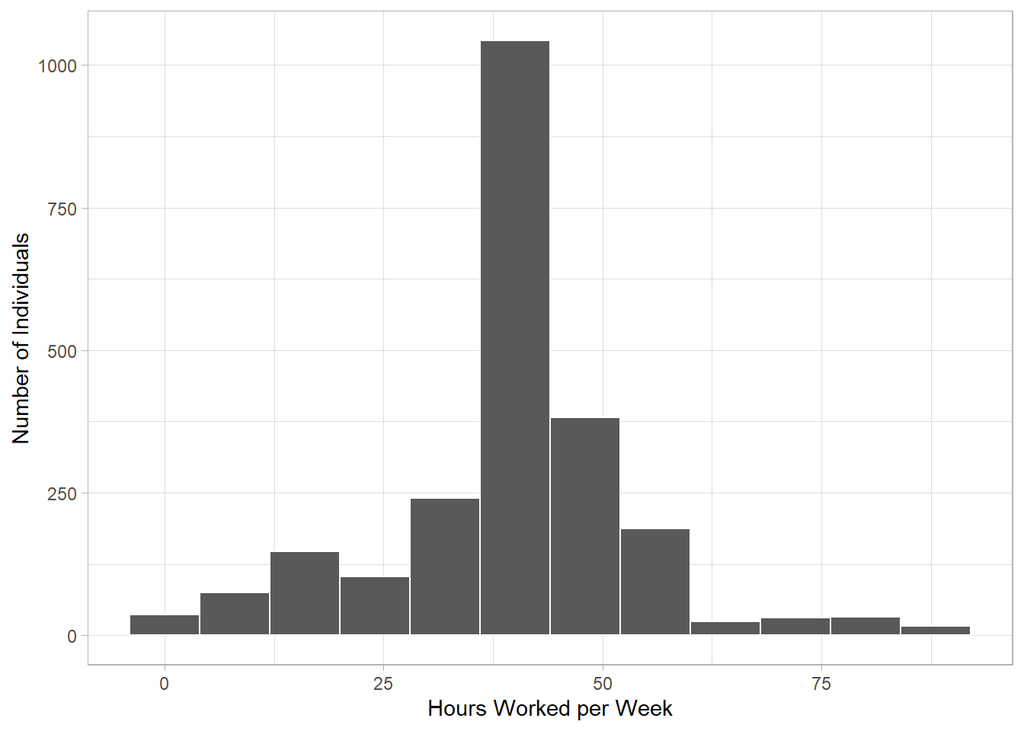

```r
ggplot(hrs_data,
       aes(x = hrs1)) +
  geom_histogram(color = "white",
                 binwidth = 8) + # set bin width to 8, typical work day
  xlab("Hours Worked per Week") +
  ylab("Number of Individuals")
```

## Probability Distribution

The following is a histogram showing the distribution of hours worked per week in the sample, alongside a superimposed probability density plot showing a normal distribution with the same mean and standard deviation as our sample.

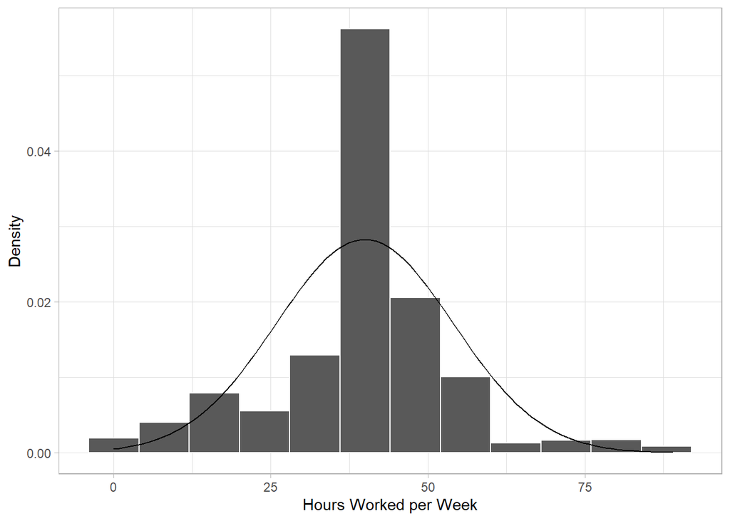

```r
ggplot(hrs_data,
       aes(x = hrs1)) +
  geom_histogram(aes(y = ..density..), # make y equal to density so the plots have the same scale
                 color = "white",
                 binwidth = 8) + # set bin width to 8, typical work day
   stat_function(fun = dnorm, # overlay dnorm function (gets probability density)
                args = list(mean = mean(hrs_data$hrs1), # mean of our sample
                            sd = sd(hrs_data$hrs1))) + #sd of our sample
  xlab("Hours Worked per Week") +
  ylab("Density")
```

# Variable #2:

The second variable from the 2022 GSS which I will use in this assignment is “age of respondent.” The options range from 18 to 89+.

```r
age_data <- gss2022 |>
  select(age) |> # select the age variable
  drop_na() # drop any rows with N/A values
```

## Mean and SD

The mean for this variable is 48. The standard deviation for this variable is 18. This indicates that within the sample, one can expect (assuming a normal distribution) that the majority of individuals will be between 30 and 66 years of age, and the vast majority will be between 12 (i.e., 18 since this is the minimum in our dataset) and 84 years of age.

## Histogram

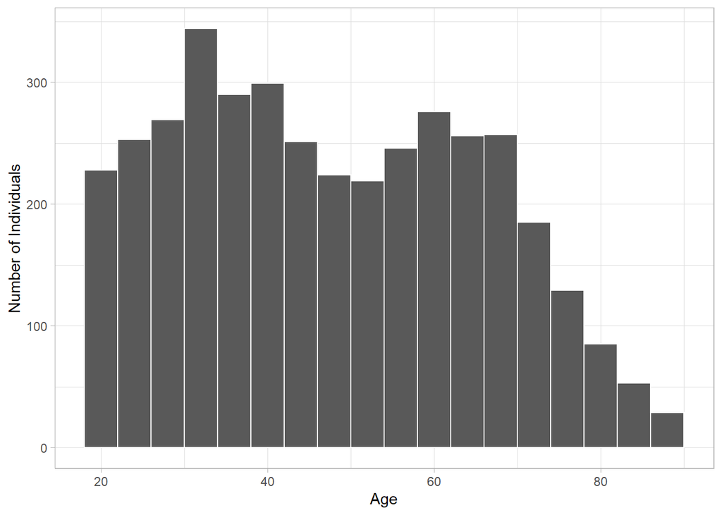

```r
ggplot(age_data,
       aes(x = age)) +
  geom_histogram(color = "white",
                 binwidth = 4) + # set bin width to 4
  xlab("Age") +
  ylab("Number of Individuals")
```

## Probability Distribution

The following is a histogram showing the distribution of ages in the sample, alongside a superimposed probability density plot showing a normal distribution with the same mean and standard deviation as our sample.

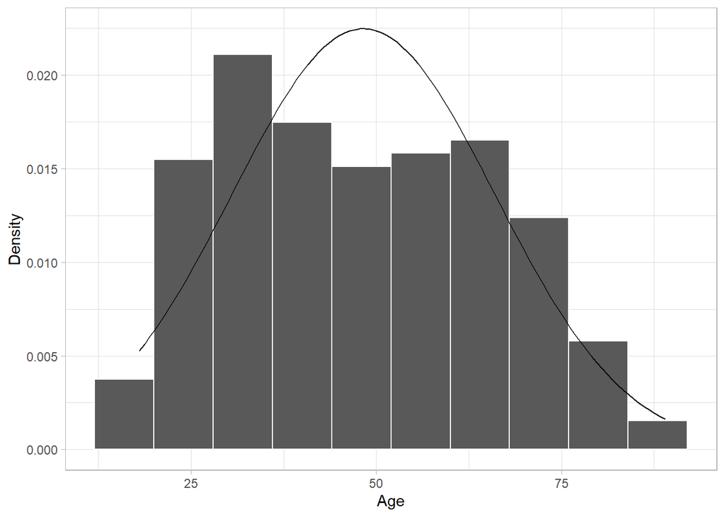

```r
ggplot(age_data,
       aes(x = age)) +
  geom_histogram(aes(y = ..density..), # make y equal to density so the plots have the same scale
                 color = "white",
                 binwidth = 8) + # set bin width to 4
   stat_function(fun = dnorm, # overlay dnorm function (gets probability density)
                args = list(mean = mean(age_data$age), # mean of our sample
                            sd = sd(age_data$age))) + #sd of our sample
  xlab("Age") +
  ylab("Density")
```

The plot above demonstrates that our sample does not map to a normal distribution effectively. The following are issues with the representation of our data from the normal distribution:

- The normal distribution will have values above 89 or below 18, both of which are not possible in our dataset (89+ are combined to 89).
- There are actually more people in the age ranges just below the mean and above the mean, with the density dropping for the age range which covers the mean. This indicates a bimodal distribution, whereas the normal distribution is unimodal.

# Formulas

This homework assignment used both the mean and standard deviation. The following are the formulas for those calculations.

## Mean

The formula for calculating the mean of a sample ($\bar{x}$) is:

$$\bar{x} = \frac{\sum_{i=1}^{n} x_i}{n}$$

## Standard Deviation

The formula for calculating the standard deviation $s$ of a sample is:

$$s = \sqrt{s^2}$$

Here, $s^2$ represents the variance which is calculated by the following formula:

### Variance

$$\frac{\sum_{i=1}^{n}(x_i-\bar{x})^2}{n-1}$$